# Normal Distribution

# Introduction

This entire paragraph was taken over from the Introduction to Statistical Thought (written by Michael Lavine; published on June 24, 2010).

It is often necessary to model a continuous random variable Y whose density is mound- shaped. Some examples are

- *Biological Anthropology* – Heights of people
- *Oceanography* – Ocean temperatures at a particular location
- *Quality Control* – Diameters of ball bearings
- *Education* – SAT scores

In each case the random variable is expected to have a central value around which most of the observations cluster. Fewer and fewer observations are farther and farther away from the center. So the pdf should be unimodal — large in the center and decreasing in both directions away from the center.

We say Y has a Normal distribution with mean μ and standard deviation σ and write Y ∼ N(μ, σ).

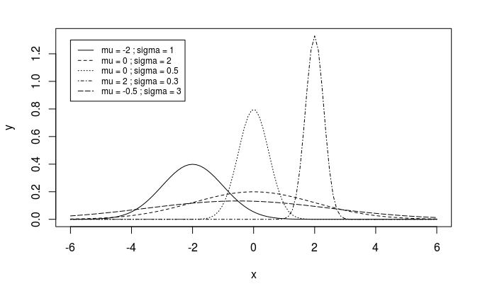

```r
x <- seq ( -6, 6, len=100 )
y <- cbind ( dnorm ( x, -2, 1 ),
dnorm ( x, 0, 2 ),
dnorm ( x, 0, .5 ),
dnorm ( x, 2, .3 ),
dnorm ( x, -.5, 3 )
)
matplot ( x, y, type="l", col=1 )
legend ( -6, 1.3, paste( "mu =", c(-2,0,0,2,-.5),
"; sigma =", c(1,2,.5,.3,3) ),
lty=1:5, col=1, cex=.75 )
```

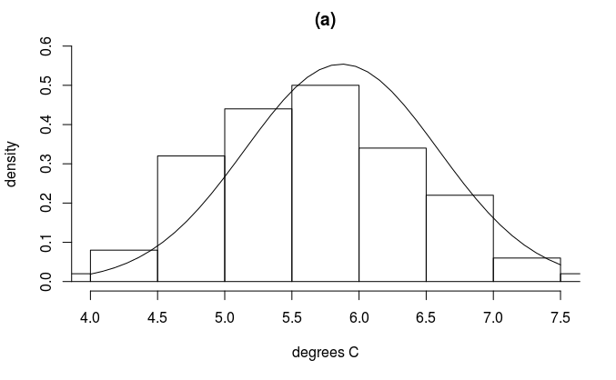

```r
samp <- rnorm ( 100, 5.87, .72 )
y.vals <- seq ( 4, 7.5, length=40 )
hist ( samp, prob=T, main="(a)",
xlim=c(4,7.5), xlab="degrees C",
ylim=c(0,.6), ylab="density" )
lines ( y.vals, dnorm(y.vals,5.87,.72) )
```

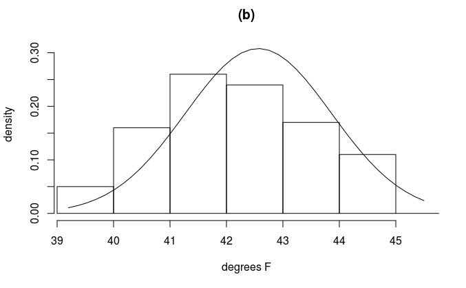

```r
y2samp <- samp * 9/5 + 32
y2.vals <- y.vals * 9/5 + 32
hist ( y2samp, prob=T, main="(b)",
xlim=c(39.2,45.5), xlab="degrees F",
ylim=c(0,1/3), ylab="density" )
lines ( y2.vals, dnorm(y2.vals,42.566,1.296) )
```

Standardization:

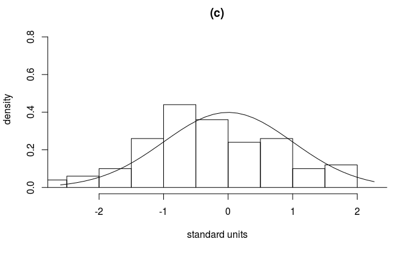

```r
zsamp <- (samp-5.87) / .72
z.vals <- (y.vals-5.87) / .72
hist ( zsamp, prob=T, main="(c)",
xlim=c(-2.6,2.26), xlab="standard units",
ylim=c(0,.833), ylab="density" )
lines ( z.vals, dnorm(z.vals,0,1) )
```

Let Y ∼ N(μ, σ) and define a new random variable Z = (Y −μ)/σ. Z is in standard units. It tells how many standard units Y is above or below its mean μ.

The N(0, 1) distribution is called the standard Normal distribution.